# IMDB Movie Classification Grid Search

Hyperparameter tuning for DNNs tends to be a bit more involved than other ML models due to the number of hyperparameters that can/should be assessed and the dependencies between these parameters. To automate the hyperparameter tuning for keras and tensorflow, we use the [**tfruns**](https://github.com/rstudio/tfruns) package.

This notebook shows an example of performing a grid search on a densley connected feedforward neural network for the IMDB movie review classifier introduced in this [case study](https://rstudio-conf-2020.github.io/dl-keras-tf/notebooks/02-imdb.nb.html).

```r
library(tfruns)
library(dplyr)
```

tfruns provides added flexibility for tracking, visualizing, and managing training runs. The most common way to use tfruns is to create an R script that contains the code to be executed. For this example, I created the imdb-grid-search.R script.

Within this script, we create “flags”, which identify the hyperparameters of interest. For this example, I assess:

- batch sizes of 128 and 512
- layers of 1, 2, and 3
- number of units per hidden layer of 16, 32, and 64
- learning rate of 0.001 and 0.0001
- dropout rates of 0, 0.3, and 0.5
- weight decay of 0, 0.01, and 0.001

This equates to 324 models. Since these models run relatively quickly, and since I ran this at the end of the day, I performed a full cartesian grid search. This means I ran and assessed every single one of the 324 models. If you are pressed for time you can run a stochastic hyperparameter grid search by using the `sample` parameter in `tuning_run` below.

Next, to execute this grid search, you first specify the grid search hyperparameter values for the flags you created in your .R script like below. You then run `tuning_run()` in place of `source()` to execute your .R script for the supplied hyperparameter grid.

*Note: this takes over 3 hours to run on a non-GPU*

```r
grid_search <- list(
  batch_size = c(128, 512),
  layers = c(1, 2, 3),
  units = c(16, 32, 64),
  learning_rate = c(0.001, 0.0001),
  dropout = c(0, 0.3, 0.5),
  weight_decay = c(0, 0.01, 0.001)
)

tuning_run("imdb-grid-search.R", flags = grid_search, confirm = FALSE, echo = FALSE)
```

This grid search execution will create a “runs” subdirectory within your working directory. This fold contains information for every single training run executed during the grid search.

To list the results you can run `ls_runs()`:

```r
data.frame(ls_runs(runs_dir = "imdb_runs"))
```

|  | run_dir | eval_best_epoch | eval_best_loss | eval_best_acc | metric_loss | metric_accuracy | metric_val_loss | metric_val_accuracy | flag_batch_size | flag_layers | flag_units | flag_learning_rate | flag_dropout | flag_weight_decay | samples | batch_size | epochs | epochs_completed | metrics | model | loss_function | optimizer | learning_rate | script | start | end | completed | output | source_code | … |
| --- | --- | --- | --- | --- | --- | --- | --- | --- | --- | --- | --- | --- | --- | --- | --- | --- | --- | --- | --- | --- | --- | --- | --- | --- | --- | --- | --- | --- | --- | --- |
| 1 | imdb_runs/2019-12-11T19-04-51Z | 23 | 0.407 | 0.891 | 0.2822 | 0.9458 | 0.4156 | 0.8918 | 512 | 3 | 64 | 1e-04 | 0.5 | 0.001 | 20000 | 512 | 100 | 33 | imdb_runs/2019-12-11T19-04-51Z/tfruns.d/metrics.json | Model\nModel: "sequential_323"\n________________________________________________________________________________\nLayer (type) Output Shape Param # \n==================================================… | binary_crossentropy |  | 1e-04 | imdb-grid-search.R | 2019-12-11 19:04:57 | 2019-12-11 19:05:57 | TRUE |  | imdb_runs/2019-12-11T19-04-51Z/tfruns.d/source.tar.gz | … |
| 2 | imdb_runs/2019-12-11T19-03-39Z | 10 | 0.396 | 0.890 | 0.2792 | 0.9370 | 0.4017 | 0.8894 | 128 | 3 | 64 | 1e-04 | 0.5 | 0.001 | 20000 | 128 | 100 | 20 | imdb_runs/2019-12-11T19-03-39Z/tfruns.d/metrics.json | Model\nModel: "sequential_322"\n________________________________________________________________________________\nLayer (type) Output Shape Param # \n==================================================… | binary_crossentropy |  | 1e-04 | imdb-grid-search.R | 2019-12-11 19:03:45 | 2019-12-11 19:04:51 | TRUE |  | imdb_runs/2019-12-11T19-03-39Z/tfruns.d/source.tar.gz | … |
| 3 | imdb_runs/2019-12-11T19-02-31Z | 25 | 0.360 | 0.893 | 0.2420 | 0.9485 | 0.3627 | 0.8920 | 512 | 2 | 64 | 1e-04 | 0.5 | 0.001 | 20000 | 512 | 100 | 35 | imdb_runs/2019-12-11T19-02-31Z/tfruns.d/metrics.json | Model\nModel: "sequential_321"\n________________________________________________________________________________\nLayer (type) Output Shape Param # \n==================================================… | binary_crossentropy |  | 1e-04 | imdb-grid-search.R | 2019-12-11 19:02:38 | 2019-12-11 19:03:39 | TRUE |  | imdb_runs/2019-12-11T19-02-31Z/tfruns.d/source.tar.gz | … |
| 4 | imdb_runs/2019-12-11T19-01-14Z | 11 | 0.353 | 0.892 | 0.2451 | 0.9413 | 0.3583 | 0.8904 | 128 | 2 | 64 | 1e-04 | 0.5 | 0.001 | 20000 | 128 | 100 | 21 | imdb_runs/2019-12-11T19-01-14Z/tfruns.d/metrics.json | Model\nModel: "sequential_320"\n________________________________________________________________________________\nLayer (type) Output Shape Param # \n==================================================… | binary_crossentropy |  | 1e-04 | imdb-grid-search.R | 2019-12-11 19:01:21 | 2019-12-11 19:02:31 | TRUE |  | imdb_runs/2019-12-11T19-01-14Z/tfruns.d/source.tar.gz | … |
| 5 | imdb_runs/2019-12-11T18-59-49Z | 41 | 0.319 | 0.888 | 0.2249 | 0.9413 | 0.3192 | 0.8888 | 512 | 1 | 64 | 1e-04 | 0.5 | 0.001 | 20000 | 512 | 100 | 51 | imdb_runs/2019-12-11T18-59-49Z/tfruns.d/metrics.json | Model\nModel: "sequential_319"\n________________________________________________________________________________\nLayer (type) Output Shape Param # \n==================================================… | binary_crossentropy |  | 1e-04 | imdb-grid-search.R | 2019-12-11 18:59:55 | 2019-12-11 19:01:14 | TRUE |  | imdb_runs/2019-12-11T18-59-49Z/tfruns.d/source.tar.gz | … |
| 6 | imdb_runs/2019-12-11T18-58-17Z | 18 | 0.311 | 0.891 | 0.2218 | 0.9349 | 0.3122 | 0.8912 | 128 | 1 | 64 | 1e-04 | 0.5 | 0.001 | 20000 | 128 | 100 | 28 | imdb_runs/2019-12-11T18-58-17Z/tfruns.d/metrics.json | Model\nModel: "sequential_318"\n________________________________________________________________________________\nLayer (type) Output Shape Param # \n==================================================… | binary_crossentropy |  | 1e-04 | imdb-grid-search.R | 2019-12-11 18:58:24 | 2019-12-11 18:59:49 | TRUE |  | imdb_runs/2019-12-11T18-58-17Z/tfruns.d/source.tar.gz | … |
| 7 | imdb_runs/2019-12-11T18-57-17Z | 28 | 0.351 | 0.893 | 0.2825 | 0.9362 | 0.3553 | 0.8944 | 512 | 3 | 32 | 1e-04 | 0.5 | 0.001 | 20000 | 512 | 100 | 38 | imdb_runs/2019-12-11T18-57-17Z/tfruns.d/metrics.json | Model\nModel: "sequential_317"\n________________________________________________________________________________\nLayer (type) Output Shape Param # \n==================================================… | binary_crossentropy |  | 1e-04 | imdb-grid-search.R | 2019-12-11 18:57:24 | 2019-12-11 18:58:17 | TRUE |  | imdb_runs/2019-12-11T18-57-17Z/tfruns.d/source.tar.gz | … |
| 8 | imdb_runs/2019-12-11T18-56-17Z | 14 | 0.345 | 0.892 | 0.2909 | 0.9258 | 0.3538 | 0.8918 | 128 | 3 | 32 | 1e-04 | 0.5 | 0.001 | 20000 | 128 | 100 | 24 | imdb_runs/2019-12-11T18-56-17Z/tfruns.d/metrics.json | Model\nModel: "sequential_316"\n________________________________________________________________________________\nLayer (type) Output Shape Param # \n==================================================… | binary_crossentropy |  | 1e-04 | imdb-grid-search.R | 2019-12-11 18:56:23 | 2019-12-11 18:57:17 | TRUE |  | imdb_runs/2019-12-11T18-56-17Z/tfruns.d/source.tar.gz | … |
| 9 | imdb_runs/2019-12-11T18-55-17Z | 31 | 0.329 | 0.893 | 0.2596 | 0.9348 | 0.3303 | 0.8940 | 512 | 2 | 32 | 1e-04 | 0.5 | 0.001 | 20000 | 512 | 100 | 41 | imdb_runs/2019-12-11T18-55-17Z/tfruns.d/metrics.json | Model\nModel: "sequential_315"\n________________________________________________________________________________\nLayer (type) Output Shape Param # \n==================================================… | binary_crossentropy |  | 1e-04 | imdb-grid-search.R | 2019-12-11 18:55:23 | 2019-12-11 18:56:17 | TRUE |  | imdb_runs/2019-12-11T18-55-17Z/tfruns.d/source.tar.gz | … |
| 10 | imdb_runs/2019-12-11T18-54-15Z | 15 | 0.328 | 0.889 | 0.2606 | 0.9286 | 0.3324 | 0.8904 | 128 | 2 | 32 | 1e-04 | 0.5 | 0.001 | 20000 | 128 | 100 | 25 | imdb_runs/2019-12-11T18-54-15Z/tfruns.d/metrics.json | Model\nModel: "sequential_314"\n________________________________________________________________________________\nLayer (type) Output Shape Param # \n==================================================… | binary_crossentropy |  | 1e-04 | imdb-grid-search.R | 2019-12-11 18:54:22 | 2019-12-11 18:55:17 | TRUE |  | imdb_runs/2019-12-11T18-54-15Z/tfruns.d/source.tar.gz | … |

[output cut: 314 more lines]

```r
ls_runs(runs_dir = "imdb_runs", order = eval_best_loss, decreasing = FALSE)
```

```
Data frame: 324 x 31
```

|  | run_dir | eval_best_loss | eval_best_epoch | eval_best_acc | metric_loss | metric_accuracy | metric_val_loss | metric_val_accuracy |
| --- | --- | --- | --- | --- | --- | --- | --- | --- |
| 228 | imdb_runs/2019-12-11T13-38-07Z | 0.262 | 18 | 0.894 | 0.1655 | 0.9431 | 0.2652 | 0.8942 |
| 222 | imdb_runs/2019-12-11T13-43-15Z | 0.263 | 13 | 0.896 | 0.1557 | 0.9455 | 0.2649 | 0.8978 |
| 227 | imdb_runs/2019-12-11T13-39-01Z | 0.263 | 39 | 0.895 | 0.1593 | 0.9485 | 0.2641 | 0.8946 |
| 221 | imdb_runs/2019-12-11T13-44-24Z | 0.264 | 28 | 0.896 | 0.1552 | 0.9487 | 0.2647 | 0.8960 |
| 233 | imdb_runs/2019-12-11T13-33-32Z | 0.264 | 53 | 0.898 | 0.1795 | 0.9426 | 0.2642 | 0.8982 |
| 258 | imdb_runs/2019-12-11T13-12-31Z | 0.264 | 11 | 0.894 | 0.1462 | 0.9502 | 0.2680 | 0.8936 |
| 269 | imdb_runs/2019-12-11T13-03-40Z | 0.264 | 42 | 0.895 | 0.1659 | 0.9482 | 0.2641 | 0.8954 |
| 270 | imdb_runs/2019-12-11T13-02-48Z | 0.264 | 22 | 0.896 | 0.1686 | 0.9420 | 0.2649 | 0.8952 |
| 264 | imdb_runs/2019-12-11T13-07-39Z | 0.265 | 16 | 0.896 | 0.1496 | 0.9495 | 0.2690 | 0.8940 |
| 268 | imdb_runs/2019-12-11T13-04-31Z | 0.265 | 14 | 0.896 | 0.1770 | 0.9421 | 0.2708 | 0.8960 |

```
# ... with 314 more rows
# ... with 23 more columns:
#   flag_batch_size, flag_layers, flag_units, flag_learning_rate, flag_dropout,
#   flag_weight_decay, samples, batch_size, epochs, epochs_completed, metrics, model,
#   loss_function, optimizer, learning_rate, script, start, end, completed, output,
#   source_code, context, type
```

To see details about any one of these models you can run `view_run()`. In this example, I take the first optimal model from above. When you execute this, a pop up window will appear with that models summary information as illustrated below.

```r
best_run <- ls_runs(
  runs_dir = "imdb_runs",
  order = eval_best_loss,
  decreasing = FALSE
  ) %>%
  slice(1) %>%
  pull(run_dir)

view_run(best_run)
```

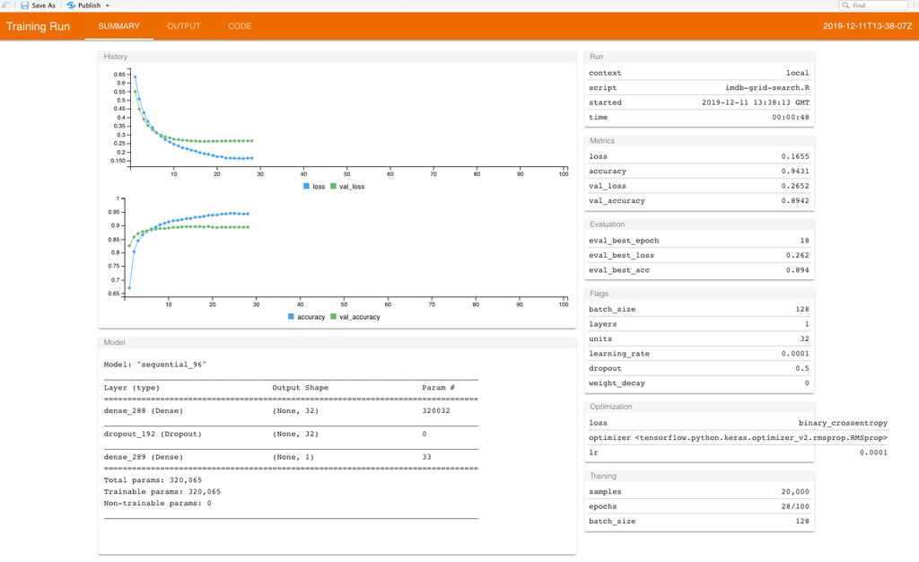

There are many other handy features to the tfruns package. I suggest you check it out at https://tensorflow.rstudio.com/tools/tfruns/overview/ and take it for a test drive.